# Coronavirus Situation In China

Dilni T Ekanayake

7/18/2020

# **Introduction**

Due to the spread of Covid-19 virus around the world, to date 14,642,861 cases of Covid 19 have been reported in 216 countries worldwide, with 8,735,298 recovered and 608,911 deaths. According to the hospital reports received by the Health Department of Wuhan City, Hubei Province, China in December 2019, the earliest case was on December 8, 2019 and it reported as unexplained pneumonia from the traditional market “South China Seafood City”. Later, some research institutions predicted that the pneumonia perhaps caused by a new virus, [3] Yu X (29 May 2020). Since then, the virus has gradually spread throughout China.

[World map of Wuhan,China] (https://www.worldmap1.com/map/china/wuhan/map%20of%20wuhan%20world.jpg)

“A study in Korea found that the risk of influenza incidence was significantly increased with low daily temperature and low relative humidity, a positive significant association was observed for diurnal temperature range (DTR) (Park et al., 2019)”. Wuhan is located in Hubei Province and one of the largest cities in Central China. Due to the location of the Yangtze River Delta, Wuhan has a typical subtropical, humid, monsoon climate with cold winters and warm summers and the average annual temperature and rainfall are 15.8 °C–17.5 °C and 1050 mm–2000 mm, respectively, [4] Yueling Ma (1 July 2020).When we talk about China, because it covers a large area, it is the country with the biggest climate change per single country. Northern China, January is the coldest month of the year and Southern China has a monsoon season. The Southern China is prone to typhoons from May to December, but especially July to September and West China has the most extreme summer to winter temperature differences and the average minimum temperature in January is -11°C. Most of China is very hot in July and August. Many studies reported that the COVID-19 was related to the meteorological factors, which decreased with the temperature increasing, but their effects on the mortality have not been reported. Therefore, we assume that the weather conditions might also contributed to the mortality of COVID-19.

Thus, due to natural causes or other reasons, as the spread of the virus increased, the Chinese government decided to close some cities and countries. China was the first country to put a lockdown into effect in a bid to curb the spread of coronavirus across the nation. The world was stunned by the country’s decision, but after two months of lockdown measures, the country has seen a huge reduction in cases. As first put Wuhan City on lockdown on January 23 and Chinese authorities meant no travel in or out of the city was allowed, even for those who had important medical or humanitarian reasons. “When the lockdown first began people were allowed out of their homes, but restrictions soon tightened. In some areas, this was limited to outings of just one member of a family every two days in order to buy necessities. Others barred residents from leaving, obligating them to order food and other supplies from couriers. When the policy later stepped up again, officials visited homes door to door to undertake health checks and force ill persons into isolation.” Then China started to relax some measures after 59 days the lockdown was first introduced and the government has ordered travellers from abroad to isolate themselves for 14 days at their homes or at government-designated centers as part of a quarantine process, [1] Kaisha Langton (30 May 2020).

Other than lockdown, Chinese government launched a series of emergency measures to respond to the challenges of the epidemic. Accordingly setup headquarters for the COVID-19 pneumonia epidemic, all of the Provinces in Mainland China launched public health emergencies response and to encourage patients to see doctor in time, the Chinese government announced that the medical expenses for the COVID-19 Pneumonia would be mainly borne by the medical insurance and government. Also decided to construct two makeshift hospital within 15 days and supported to all researchers, Pharmaceutical companies for their research. Furthermore government was authorized to mobilize and expropriate all kinds of personnel, materials, transportation and related facilities to block the epidemic area, to restrict or stop the market, assembly, theater performance and other group gathering activities, to declare the suspension of work, business and class [3] Yu X (29 May 2020).

The virus is now spreading all over the world. “COVID-19 is a serious illness, and it’s much more dangerous than the flu. One Centers for Disease Control and Prevention (CDC) projection suggests that between 160 to 214 million people will eventually be infected in the US and that between 200,000 and 1.7 million could die.” [2] Nicole Wetsman (7 July 2020). Therefore everyone should know about the virus and protection methods. The symptoms of COVID-19 have ranged from mild, like those in a cold, to severe. Sometimes don’t require hospitalization, but cases are critical and can be die. The virus moves rapidly, “It also probably spreads when an infected person sneezes or coughs. Coughs and sneezes produce little droplets of mucus and saliva. If these droplets make it into another person’s eyes, mouth, or nose, they can get sick. The viruses in those little droplets can also fall onto surfaces, like tables or doorknobs — if someone touches that surface and touches their eyes, mouth, or nose, they can also get sick.” The dangerous side, there aren’t any proven treatments for COVID-19. Therefore it is important to protect ourselves and others. For that stay home as much as possible even if you’re not feeling sick, wear a cloth mask or face covering when you’re out in public, and wash your hands often, [2] Nicole Wetsman (7 July 2020).

# **Data Analysis and Results**

## **Data**

```r
data(coronavirus)
head(coronavirus)
```

| date | province | country | lat | long | type | cases |
| --- | --- | --- | --- | --- | --- | --- |
| 2020-01-22 |  | Afghanistan | 33 | 65 | confirmed | 0 |
| 2020-01-23 |  | Afghanistan | 33 | 65 | confirmed | 0 |
| 2020-01-24 |  | Afghanistan | 33 | 65 | confirmed | 0 |
| 2020-01-25 |  | Afghanistan | 33 | 65 | confirmed | 0 |
| 2020-01-26 |  | Afghanistan | 33 | 65 | confirmed | 0 |
| 2020-01-27 |  | Afghanistan | 33 | 65 | confirmed | 0 |

Table 01: coronavirus data set

- For futher analysis this coronavirus data set was used.

```
##       date              province           country               lat
##  Min.   :2020-01-22   Length:87695       Length:87695       Min.   :-51.796
##  1st Qu.:2020-02-18   Class :character   Class :character   1st Qu.:  6.611
##  Median :2020-03-17   Mode  :character   Mode  :character   Median : 22.300
##  Mean   :2020-03-17                                         Mean   : 20.848
##  3rd Qu.:2020-04-14                                         3rd Qu.: 40.143
##  Max.   :2020-05-12                                         Max.   : 71.707
##       long             type               cases
##  Min.   :-135.00   Length:87695       Min.   :    0.00
##  1st Qu.: -14.45   Class :character   1st Qu.:    0.00
##  Median :  21.75   Mode  :character   Median :    0.00
##  Mean   :  24.27                      Mean   :   69.22
##  3rd Qu.:  81.00                      3rd Qu.:    1.00
##  Max.   : 178.06                      Max.   :36188.00
```

Figure 01: Summery of coronavirus data set

| date | province | country | lat | long | type | cases |
| --- | --- | --- | --- | --- | --- | --- |
| 2020-01-22 | Anhui | China | 31.8 | 117 | confirmed | 1 |
| 2020-01-23 | Anhui | China | 31.8 | 117 | confirmed | 8 |
| 2020-01-24 | Anhui | China | 31.8 | 117 | confirmed | 6 |
| 2020-01-25 | Anhui | China | 31.8 | 117 | confirmed | 24 |
| 2020-01-26 | Anhui | China | 31.8 | 117 | confirmed | 21 |
| 2020-01-27 | Anhui | China | 31.8 | 117 | confirmed | 10 |

Table 02: coronavirus data set for China

*There are 33 provices coronavirus cases recorded due to type (confirmed, death, recovered) and due to date.

## **Data Analysis**

| type | total_Cases |
| --- | --- |
| confirmed | 84019 |
| death | 4637 |
| recovered | 80193 |

Table 03: Total comfirmed, death and recovered cases in China

According to the table 03 and figure 02, total of recovered cases are approximately equal to total of confirmed cases and Almost completely large than to total of death cases. This implies that most of the confirmed cases were recovered. This is further illustrated by figure 03. Confirmed and recovered medians are nearly equal and death median is relatively low. Furthermore box plot shows that data of cases spread in large range but the medians of all types are low. This means most of the cases have less value.

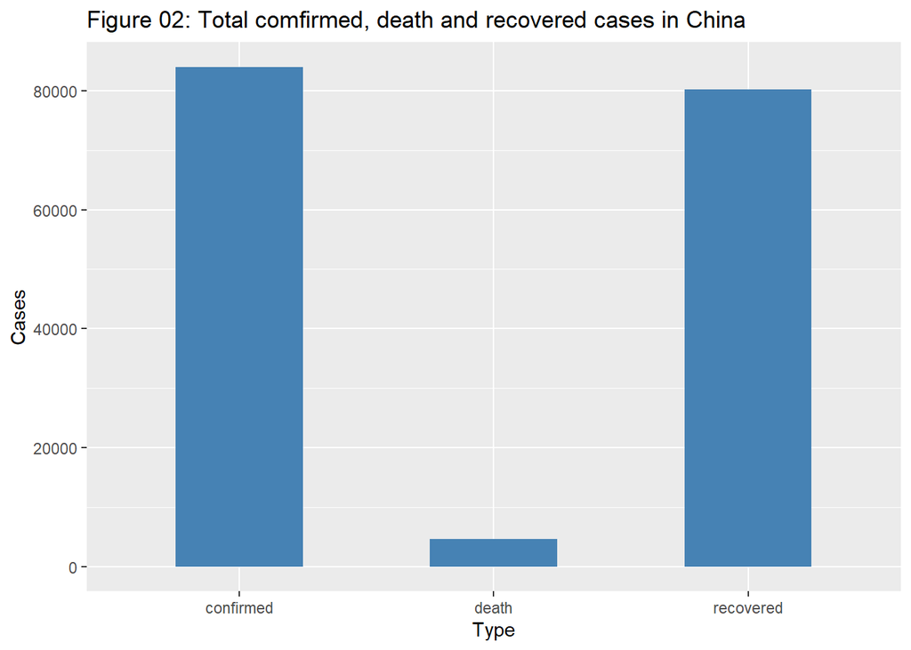

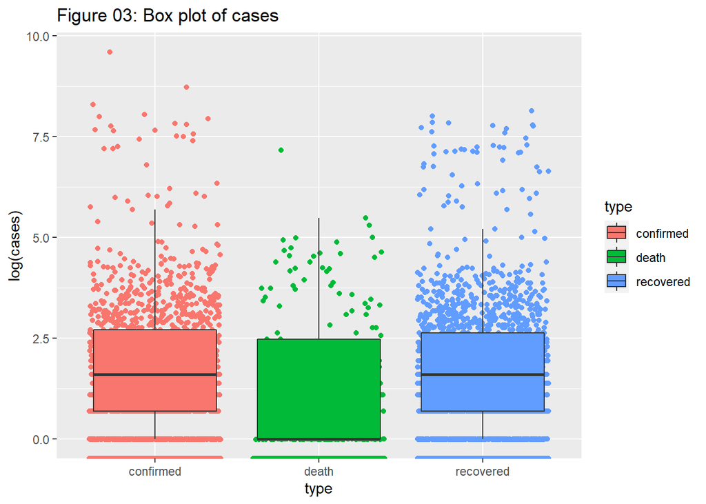

| province | confirmed_sum | death_sum | recovered_sum |
| --- | --- | --- | --- |
| Hubei | 68134 | 4512 | 64564 |
| Guangdong | 1589 | 8 | 1578 |
| Henan | 1276 | 22 | 1254 |
| Zhejiang | 1268 | 1 | 1267 |
| Hong Kong | 1047 | 4 | 992 |
| Hunan | 1019 | 4 | 1015 |
| Anhui | 991 | 6 | 985 |
| Heilongjiang | 945 | 13 | 933 |
| Jiangxi | 937 | 1 | 936 |
| Shandong | 788 | 7 | 777 |
| Shanghai | 660 | 7 | 632 |
| Jiangsu | 653 | 0 | 653 |
| Beijing | 593 | 9 | 573 |
| Chongqing | 579 | 6 | 573 |
| Sichuan | 561 | 3 | 558 |
| Fujian | 356 | 1 | 354 |
| Hebei | 328 | 6 | 321 |
| Shaanxi | 308 | 3 | 297 |
| Guangxi | 254 | 2 | 253 |
| Inner Mongolia | 209 | 1 | 190 |
| Shanxi | 198 | 0 | 199 |
| Tianjin | 191 | 3 | 186 |
| Yunnan | 185 | 2 | 183 |
| Hainan | 168 | 6 | 172 |
| Guizhou | 148 | 2 | 148 |
| Liaoning | 147 | 2 | 144 |
| Gansu | 139 | 2 | 137 |
| Jilin | 133 | 1 | 108 |
| Xinjiang | 76 | 3 | 73 |
| Ningxia | 75 | 0 | 77 |
| Macau | 45 | 0 | 42 |
| Qinghai | 18 | 0 | 18 |
| Tibet | 1 | 0 | 1 |

Table 04: total comfirmed, death and recovered cases according to province

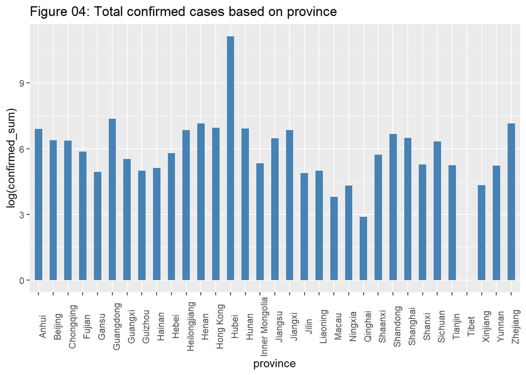

Based on table 04 and figure 04, province Hubei has highest confirmed cases (68,134) and secondly highest is Guangdong (1,589 cases). And also Hubei shows relatively high value than other provinces. Cases gap of highest to provinces is 66,545. Province Tibet shows only one confirmed case and it is the lowest. Quinghai is the second lowest province and it had 18 confirmed cases.

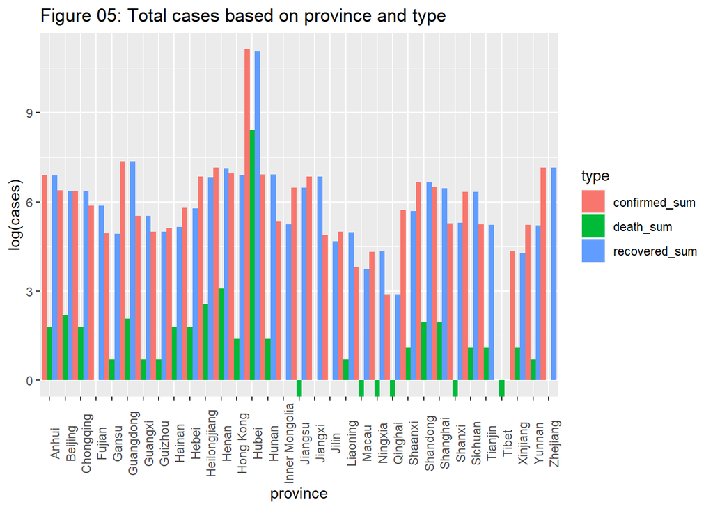

Figure 05 shows that all the provinces total confirmed cases and total recovered cases are relatively equal or completely equal. Also total death cases are very low compared to other type’s total. Some provinces didn’t have death cases.

$$Infection Fatality Rate (IFR) = \frac{Deaths}{Cases}* 100%$$

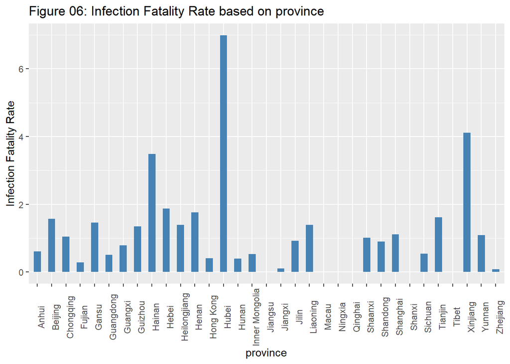

According to figure 06, Hubei has highest IFR and it 7%. Xinjiang and Hainan are Second and third highest respectively. When consider the all provinces, IFR is less than to 10%. That also shows the total death cases are very lower than total recovered cases.

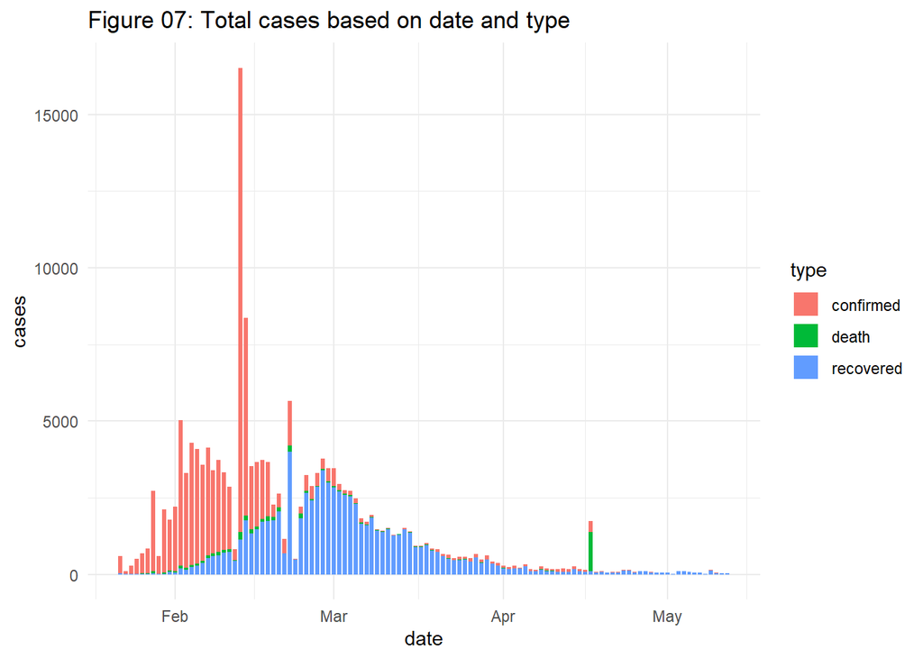

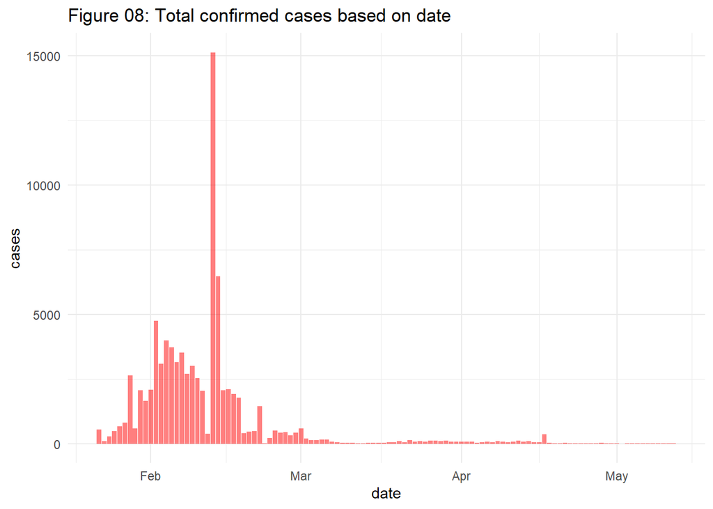

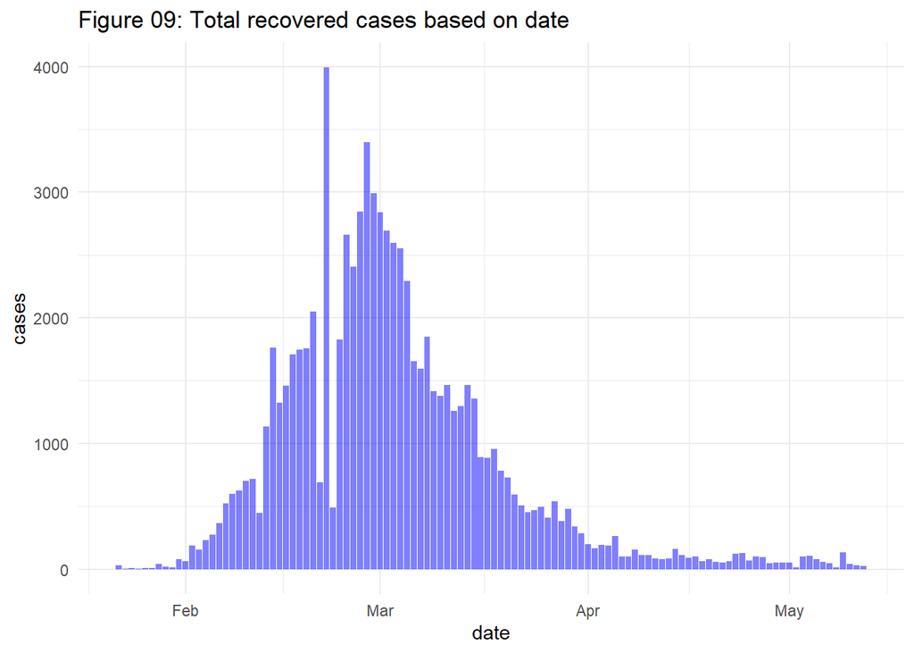

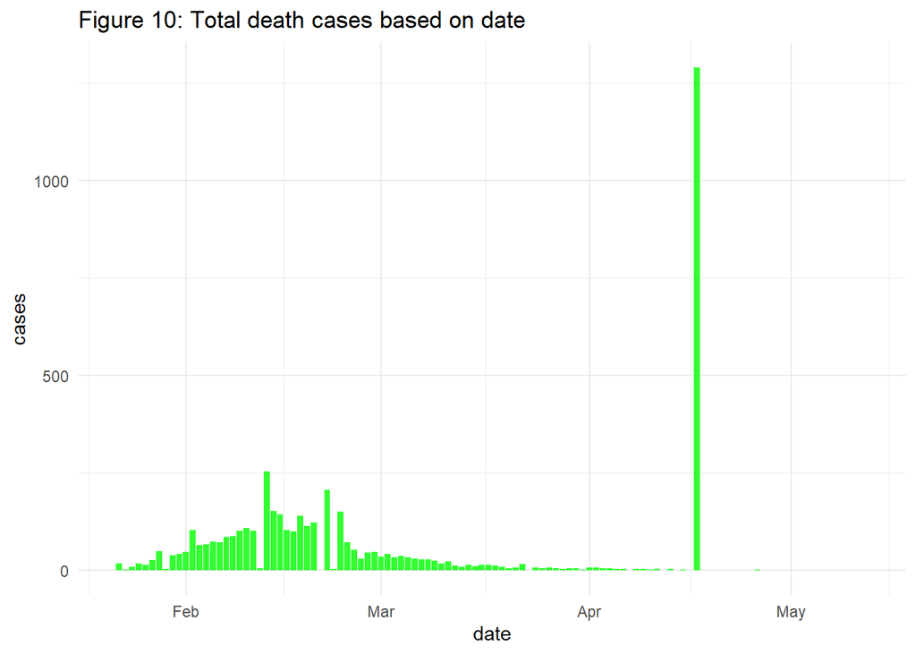

According to figures 7- 10, figure 08 shows that, the number of confirmed cases gradually increases during the period from January to mid-February and it gradually decreases during the period from mid-February to March. Shows the maximum confirmed cases during the month of February and it approximately near to 15,000. The number of confirmed cases has been gradually declining since March.

Figure 10 shows that, during the period from February to April the number of death cases shows a gradual increase and decrease. While this is relatively low, there is a sudden increase in the number of death cases in late April and it near to 1,250.

Furthermore figure 11, Table 05 and Figure 12, clearly shows the observations shown above.

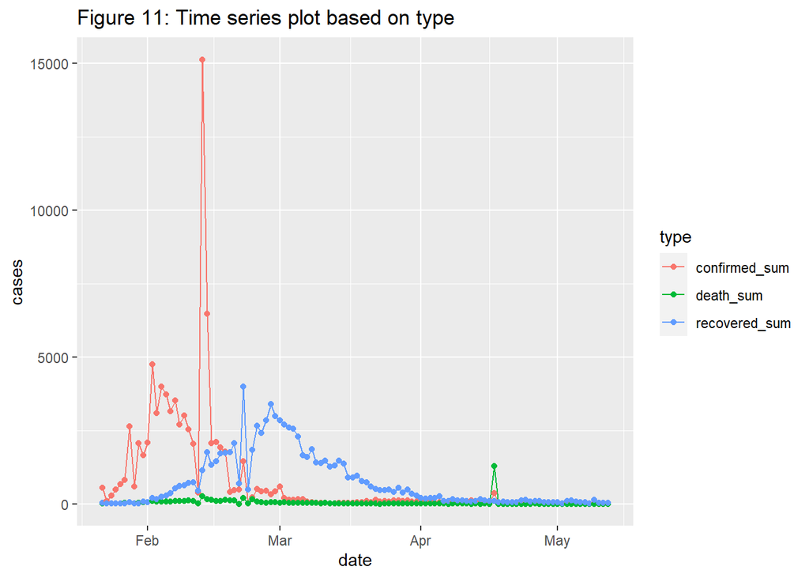

| month | type | sum_cases |
| --- | --- | --- |
| 01 | confirmed_sum | 9802 |
| 01 | death_sum | 213 |
| 01 | recovered_sum | 214 |
| 02 | confirmed_sum | 69554 |
| 02 | death_sum | 2624 |
| 02 | recovered_sum | 39120 |
| 03 | confirmed_sum | 2924 |
| 03 | death_sum | 472 |
| 03 | recovered_sum | 36887 |
| 04 | confirmed_sum | 1677 |
| 04 | death_sum | 1328 |
| 04 | recovered_sum | 3272 |
| 05 | confirmed_sum | 62 |
| 05 | death_sum | 0 |
| 05 | recovered_sum | 700 |

Table 05: Monthy total cases

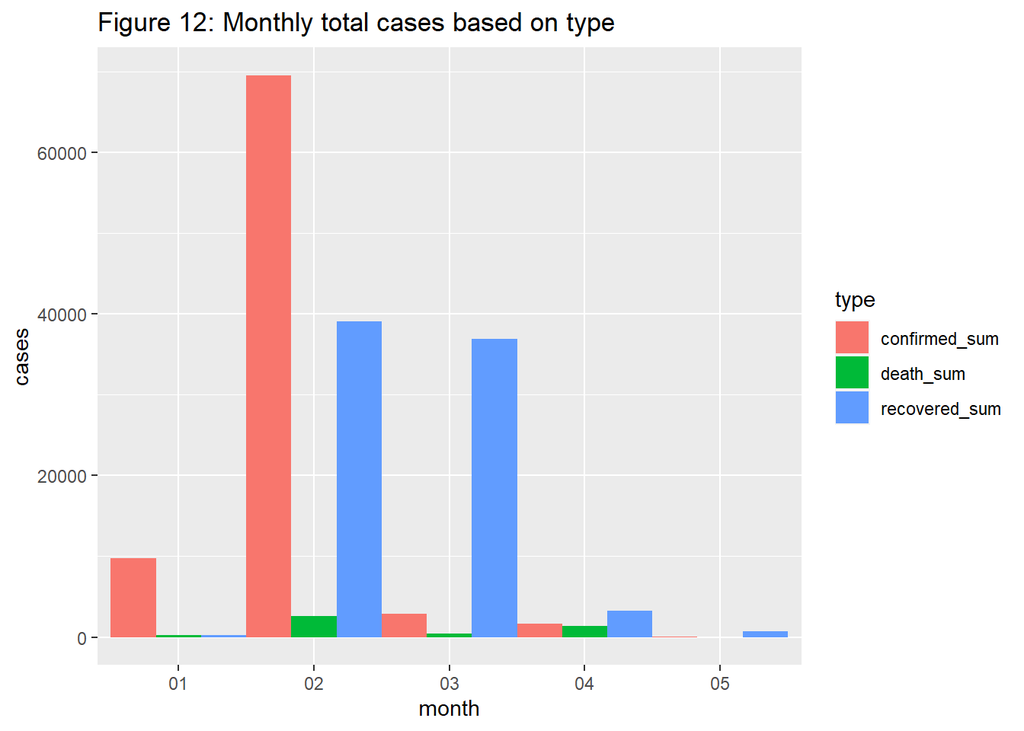

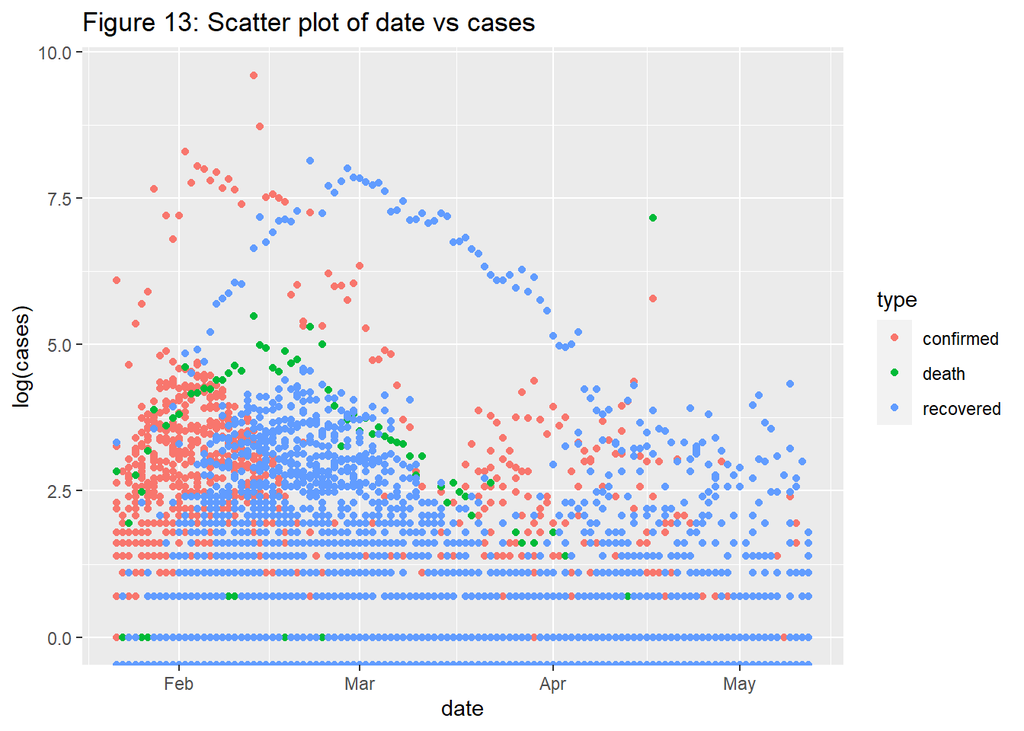

According to the figure, there is no relationship between date and cases.

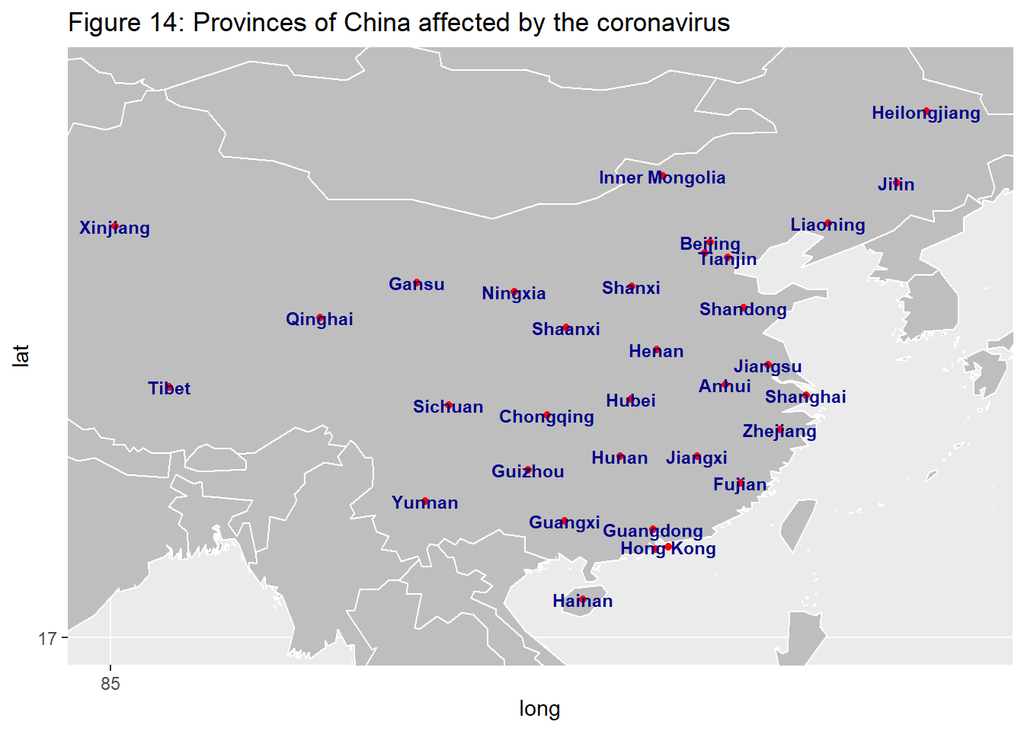

| province | confirmed_sum | death_sum | recovered_sum |
| --- | --- | --- | --- |
| Anhui | 991 | 6 | 985 |
| Chongqing | 579 | 6 | 573 |
| Henan | 1276 | 22 | 1254 |
| Hubei | 68134 | 4512 | 64564 |
| Hunan | 1019 | 4 | 1015 |

Table 06:total cases of provinces near to Hubei

[figure not shown]

According to the table 06 and figure 15, total confirmed cases of provinces near to Hubei are relatively very low. That means the virus has not spread to other provinces like in Hubei.

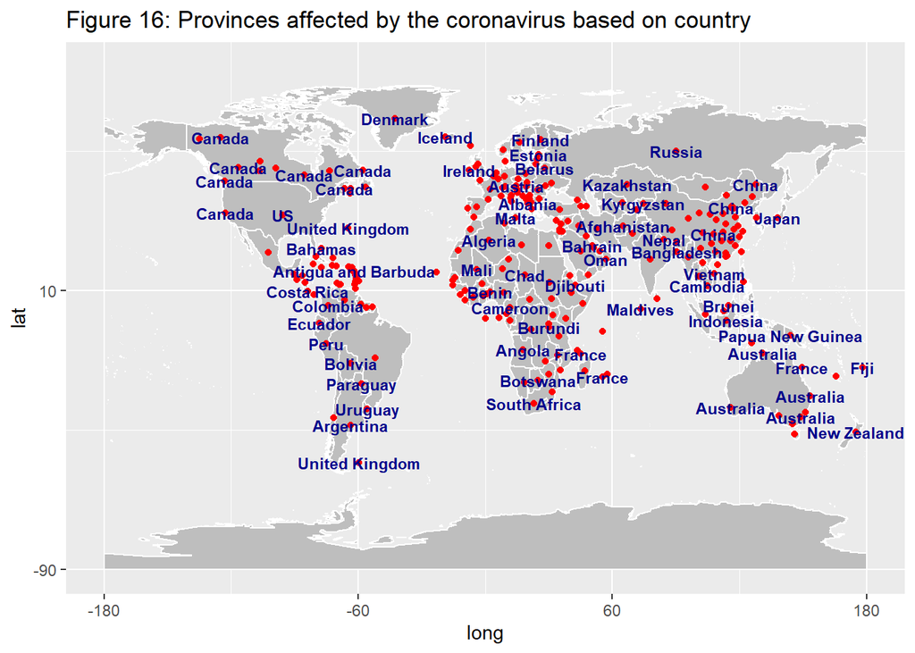

| country | confirmed_sum | death_sum | recovered_sum |
| --- | --- | --- | --- |
| US | 1369376 | 82356 | 232733 |
| Spain | 238064 | 26920 | 138980 |
| Russia | 232243 | 2116 | 43512 |
| United Kingdom | 227742 | 32770 | 1367 |
| Italy | 221216 | 30911 | 109040 |
| France | 183088 | 26994 | 57898 |
| Brazil | 178214 | 12461 | 72597 |
| Germany | 173171 | 7769 | 147200 |
| Turkey | 141475 | 3894 | 98889 |
| Iran | 110767 | 6733 | 88357 |
| China | 84019 | 4637 | 80193 |

Table 06: 11 countries with the highest number of reported confirmed cases

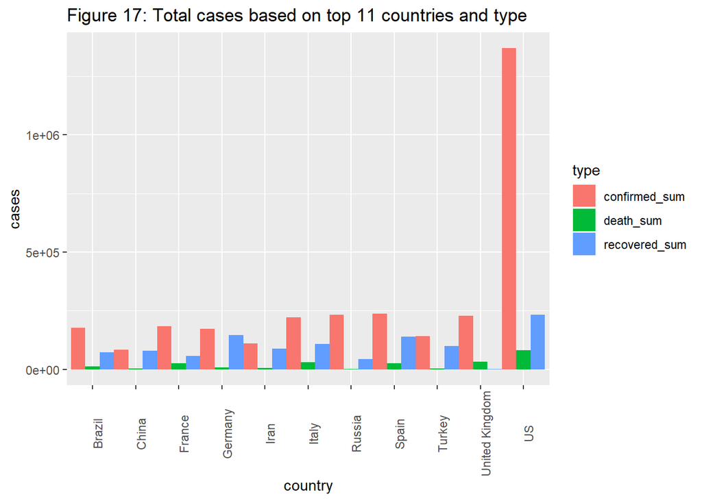

| country | confirmed_sum | death_sum | recovered_sum |
| --- | --- | --- | --- |
| Afghanistan | 4963 | 127 | 610 |
| Bhutan | 11 | 0 | 5 |
| Burma | 180 | 6 | 76 |
| China | 84019 | 4637 | 80193 |
| India | 74292 | 2416 | 24420 |
| Kazakhstan | 5279 | 36 | 2223 |
| Kyrgyzstan | 1037 | 12 | 709 |
| Laos | 19 | 0 | 14 |
| Mongolia | 42 | 0 | 15 |
| Nepal | 217 | 0 | 33 |
| Pakistan | 34336 | 737 | 8820 |
| Russia | 232243 | 2116 | 43512 |
| Tajikistan | 729 | 21 | 0 |
| Vietnam | 288 | 0 | 262 |

Table 07: Boder counries of China

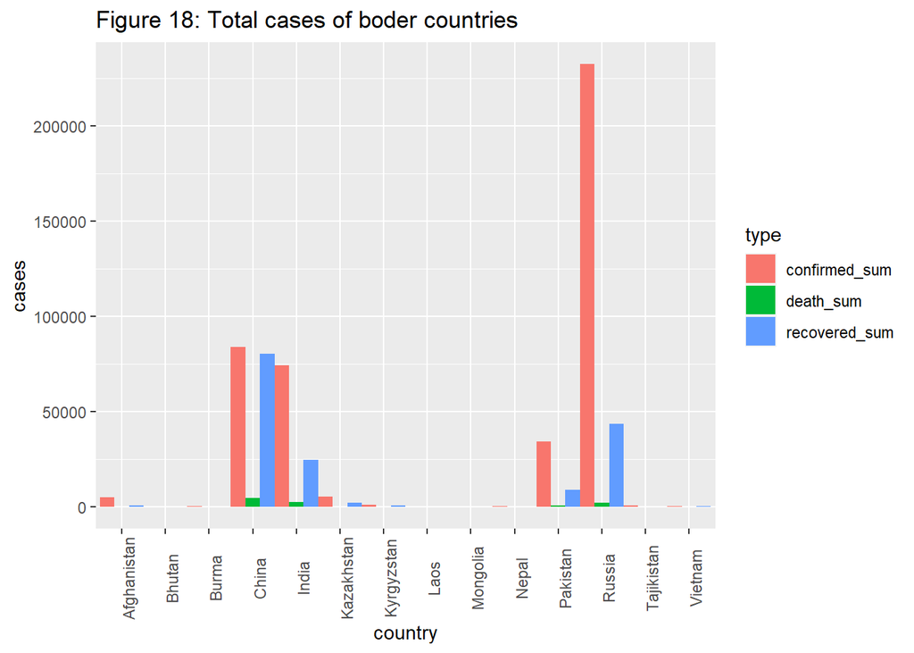

According to figure 18, only Russia, Pakistan and India has relatively high total cases compare to other border countries. Out of those 3 countries, Russia has the highest number of confirmed cases and it is over 200000. Russia’s recovered sum is lower than China’s and higher than India’s. And the recovered sum is very low compared to the number of confirmed cases in Russia. The situation is similar in India and Pakistan.

# **Conclusins and Discussion**

China is the country where the virus originated. But the number of reported cases in China is low compared to other countries. Especially with US. China is also the country with the highest number of cured patients compared to the reported number. Similar situation on when compared with border countries of China. Confirmed cases in China was lower than to Russia. Pakistan, India and Russia recovered cases were relatively lower than to confirmed cases. This shows that the actions taken by the Chinese government to control the virus have been successful. Also that some other countries have not taken appropriate actions or there has been a delay in taking actions.

# **References**

**[1]** Kaisha Langton. May 30, 2020. China lockdown: How long was China on lockdown?. Available from: (https://www.express.co.uk/travel/articles/1257717/china-lockdown-how-long-was-china-lockdown-timeframe-wuhan )

**[2]** Nicole Wetsman. July 07, 2020. Everything you need to know about the coronavirus, *THE WERGE*. ( https://www.theverge.com/ )

**[3]** Yu x, Li N. May 14, 2020. How Did Chinese Government Implement Unconventional Measures Against COVID-19 Pneumonia. *Dovepress*. 2020:13 Pages 491—499. DOI :https://doi.org/10.2147/RMHP.S251351

**[4]** Yueling Ma, Yadong Zhao, Jiangtao Liu, Xiaotao He, Bo Wang, Shihua Fu, Jun Yan, Jingping Niu, Ji Zhou and Bin Luo. July 01, 2020. Effects of temperature variation and humidity on the death of COVID-19 in Wuhan, China. *Science of The Total Environment* : 724. DOI: https://doi.org/10.1016/j.scitotenv.2020.138226